# NYPD Allegations

- **See the main project notebook for instructions to be sure you satisfy the rubric!**
- See Project 03 for information on the dataset.
- A few example prediction questions to pursue are listed below. However, don't limit yourself to them!
  - Predict the outcome of an allegation (might need to feature engineer your output column).
  - Predict the complainant or officer ethnicity.
  - Predict the amount of time between the month received vs month closed (difference of the two columns).
  - Predict the rank of the officer.

Be careful to justify what information you would know at the "time of prediction" and train your model using only those features.

```python
import matplotlib.pyplot as plt
import numpy as np
import os
import pandas as pd
import seaborn as sns
import re

from sklearn.tree import DecisionTreeRegressor
from sklearn.tree import DecisionTreeClassifier
from sklearn.neighbors import KNeighborsClassifier
from sklearn.ensemble import RandomForestClassifier
from sklearn.model_selection import train_test_split
from sklearn.preprocessing import FunctionTransformer
from sklearn.preprocessing import StandardScaler
from sklearn.preprocessing import OneHotEncoder
from sklearn.pipeline import Pipeline
from sklearn.compose import ColumnTransformer
from sklearn.decomposition import PCA

%matplotlib inline
%config InlineBackend.figure_format = 'retina'  # Higher resolution figures
```

# Summary of Findings

### Introduction

- In this project, we are trying to predict the outcome of the allegations that are sent to NYPD officers who are being accused of wrongdoing and misdemeanor. The goal of this model is to predict whether a given allegation will be "substantiated".The model will saves time and energy for the invesitgators from police department when they are trying to figuring out if the accused wrongdoing actually occured. For example, if the outcome of a prediction gives you "substantiated ", then you know that the allegation you have is probably true and with careful investigation, the police officer might be substantiated with the given charges.
- After buliding the model, we will carefully examine its effectiveness and moral implications. That is being said that a good model designed to solve attempted probelm should be good at accomplishing two goals: First, our model must reach certain amount of precision and accuracy with respect to different subpopulations with which our model is trying to predict.Second, it should be and must be fair enough. We will do pairty test on our model and see if the model is lack of fairness or bias against certain subgroups. Should the model turns out to be not fair enough, additional processes are needed to make sure that people whose welfare depends on the ourcome of this model, are being treated fairly and responsibly.
- To be more specific, the metrics to evaluate the performance of our model are accuracy,recall, specificity, precison as well as f1 score. On the other hand, in oder to evaluate the fairness of our model, applications of parity test and permutation test will play important roles in our assessment. The result will be demonstrated below. ### Baseline Model
  - The features we used for building our model are:'rank_incident','mos_ethnicity','mos_gender','complainant_ethnicity','complainant_gender','fado_type'. Those variables are nominal so we use one hot encoder to deal with them when they are put on the pipeline model.
  - The numerical feature we used on buliding the model are 'mos_age_incident','complainant_age_incident'. We leave it as is and use them directly in our prediction
  - We only use prediction score to evaluate the performance of our baseline model.The score is about 69 percent, which is very bad. Clearly, we need some improvements on the feature selection process and add more features to our models. Also, it may also takes time to find the best perameters combination will be used in our model. But we defintely need to do that so that we can improve our model's performance.
  - Let's look at the perfomance of our model on a deeper level. We get 5034 true negative,1113 false positive,1439 false negative, and 684 true positive. The outcome here is very concerning. This outcome means that our model is not good at predicting positive result. If the allegation is not correct and the accused wrongdoing of the officer could not be substantiated, our model might lebel the allegation as "Substantiated" casuing the officer to be punished when he or she did not do anything wrong.
  - In conlusion, bad performance on predicting certain outcome and lack of overall accuracy tells us that this baseline model needs improvements. Below are the evaluation metrics being used: Accuracy Score: 0.69; Recall:0.322;Specificity:0.8189;Precision:0.38.False Discovery Rate:0.619.

# Code

```python
# Before doing anyting, let's import the data
path=os.path.join("data","allegations_202007271729.csv")
allegations=pd.read_csv(path)
```

```python
# cleaning disposition: keep general disposition -- Substantiated, Exonerated, Unsubstantiated
allegations['board_disposition'] = allegations['board_disposition'].apply(lambda x: x.split(' ')[0])
```

### To construct the classifier, we have to impute the missingness:

- Drop the null values if the number of missingness is relative small (under 1000):
  - allegation
  - precinct
  - contact_reason
  - outcome_description
- categorical variable (command_at_incident, complainant_ethnicity, complainant_gender):
  - making another category ('missing') to fill the missing values
- quantative variables (complainant_age_incident):
  - probabilistic Imputation to perserve the original mean and variance

```python
# number of missingness is relative small
allegations = allegations.dropna(subset = ['allegation', 'precinct','contact_reason','outcome_description'])
```

```python
# categorical variables fillna with missing
allegations = allegations.assign(**{"command_at_incident": allegations['command_at_incident'].fillna('missing'),
                                 'complainant_ethnicity': allegations['complainant_ethnicity'].fillna('missing'),
                                 'complainant_gender': allegations['complainant_gender'].fillna('missing')})
```

```python
allegations['complainant_age_incident'] = allegations['complainant_age_incident'].apply(lambda x: x if x > 0 else np.nan)
```

```python
# use probabilistic to impute quantative variables
# number of nulls
num_null = allegations['complainant_age_incident'].isnull().sum()
# draw fill vals from distribution
fill_values = allegations['complainant_age_incident'].dropna().sample(num_null, replace=True)
# align the index, which is missing?
fill_values.index = allegations.loc[allegations['complainant_age_incident'].isnull()].index
allegations = allegations.fillna({'complainant_age_incident': fill_values.to_dict()})  # fill the vals
```

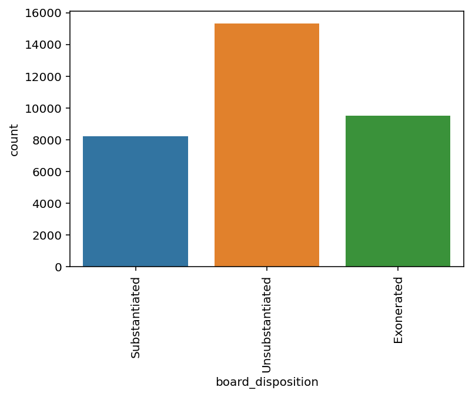

```python
sns.countplot(data = allegations,x = 'board_disposition')
plt.xticks(rotation=90)
```

```python
allegations['board_disposition'] = allegations['board_disposition'].apply(lambda x: 1 if x == 'Substantiated' else 0)
```

### Baseline Model

```python
# one-hot encode
one_hot_feat = ['rank_incident', 'mos_ethnicity','mos_gender',\
                'complainant_ethnicity','complainant_gender','fado_type']
age_feat = ['mos_age_incident','complainant_age_incident']
preproc = ColumnTransformer(transformers=[('one-hot', OneHotEncoder(sparse=False,handle_unknown='ignore'), one_hot_feat),
                                              ('age', FunctionTransformer(lambda x:x), age_feat)])
pl = Pipeline([
            ('preprocessor', preproc),
            ('tree', DecisionTreeClassifier())
])

# features
X = allegations.drop('board_disposition', axis=1)
# outcome
y = allegations.board_disposition

# split train/test set
X_train, X_test, y_train, y_test = train_test_split(X, y)
pl.fit(X_train, y_train)
display(pl.score(X_train, y_train))
display(pl.score(X_test, y_test))
```

```
0.9149502196783426
```

```
0.6914147521160823
```

```python
from sklearn import metrics
```

```python
# evaluate the model
preds = pl.predict(X_test)
print(metrics.accuracy_score(y_test, preds))
print(metrics.confusion_matrix(y_test, preds))
print(metrics.recall_score(y_test, preds))
print(metrics.recall_score(y_test, preds, pos_label=0))
print(metrics.precision_score(y_test, preds))
print(1 - metrics.precision_score(y_test, preds))
```

```
0.6914147521160823
[[5034 1113]
 [1439  684]]
0.32218558643429107
0.8189360663738409
0.3806343906510851
0.6193656093489148
```

### Final Model

```python
# feature added one; Time taken to process the complaint
allegations["time_elapsed"]= allegations['year_closed']+allegations['month_closed']/12 - \
                          allegations['year_received']-allegations['month_received']/12
```

```python
from sklearn.model_selection import GridSearchCV
```

```python
one_hot_feat = ['rank_incident', 'mos_ethnicity',\
                'complainant_ethnicity','fado_type','outcome_description','precinct']
same_feat = ['mos_age_incident','complainant_age_incident','time_elapsed']
preproc = ColumnTransformer(transformers=[('one-hot', OneHotEncoder(sparse=False,handle_unknown='ignore'), one_hot_feat),
                                              ('same', FunctionTransformer(lambda x:x), same_feat)])
pl = Pipeline([
            ('preprocessor', preproc),
            ('tree', RandomForestClassifier())
])

# features
X = allegations.drop({'board_disposition'}, axis=1)
# outcome
y = allegations.board_disposition

# split train/test set
X_train, X_test, y_train, y_test = train_test_split(X, y)
pl.fit(X_train, y_train)


 #.score Return the mean accuracy on the given test data and labels.
display('Mean accuracy in train data : {:.2f}'.format(pl.score(X_train, y_train)))
display('Mean accuracy in test data : {:.2f}'.format(pl.score(X_test, y_test)))
```

```
'Mean accuracy in train data : 0.95'
```

```
'Mean accuracy in test data : 0.77'
```

```python
# evaluate the model
preds = pl.predict(X_test)
print(metrics.accuracy_score(y_test, preds))
print(metrics.confusion_matrix(y_test, preds))
print(metrics.recall_score(y_test, preds))
print(metrics.recall_score(y_test, preds, pos_label=0))
print(metrics.precision_score(y_test, preds))
print(1 - metrics.precision_score(y_test, preds))
recall=metrics.recall_score(y_test, preds)
precision=metrics.precision_score(y_test, preds)
F1=2*((recall)*(precision))/(recall+precision)
```

```
0.771584038694075
[[5670  528]
 [1361  711]]
0.34314671814671815
0.914811229428848
0.5738498789346247
0.4261501210653753
```

### Fairness Evaluation

```python
# Visualize the demongraphic parity
X_test=X_test.reset_index(drop=True)
X_test["is_young"]=(allegations["mos_age_incident"]<= 21).replace({True:'young', False:'old'})
X_test["prediction"]=preds
y= y_test.reset_index(drop=True)
X_test['tag'] = y
```

```python
# Accuracy Parity

(
    X_test
    .groupby('is_young')
    .apply(lambda x: metrics.accuracy_score(x.tag, x.prediction))
    .rename('accuracy')
    .to_frame()
)
```

| is_young | accuracy |
| --- | --- |
| old | 0.771331 |
| young | 0.625000 |

```python
obs = X_test.groupby('is_young').apply(lambda x: metrics.accuracy_score(x.tag, x.prediction)).diff().iloc[-1]

metrs = []
for _ in range(10000):
    s = (
        X_test[['is_young', 'prediction', 'tag']]
        .assign(is_young=X_test.is_young.sample(frac=1.0, replace=False).reset_index(drop=True))
        .groupby('is_young')
        .apply(lambda x: metrics.accuracy_score(x.tag, x.prediction))
        .diff()
        .iloc[-1]
    )
    metrs.append(s)
```

```python
print(pd.Series(metrs <= obs).mean())
```

```
0.248
```